# The family of two-piece distributions

[F. Javier Rubio](https://sites.google.com/site/fjavierrubio67/) and [Mark F. J. Steel](http://www.warwick.ac.uk/go/msteel/)

January 29, 2020

# The family of two-piece distributions

This R markdown contains illustrative examples about the family of two-piece distributions and the `twopiece’ R package. A more detailed description of the family of two-piece distributions can be found at Rubio and Steel (2020). Additional examples on the twopiece R package can be found at “[twopiece R package](http://rpubs.com/FJRubio/twopiece)”.

Suppose that $f$ is a unimodal symmetric (about $0$) probability density function (pdf) from the location-scale family, possibly including a shape parameter $\delta$. Then, the pdf of a member of the two-piece family of distributions is:
$$s\left(x; \mu,\sigma_1,\sigma_2, \delta\right) =
\begin{cases}
\dfrac{2}{\sigma_1+\sigma_2}f\left(\dfrac{x-\mu}{\sigma_1};\delta\right), \mbox{if } x < \mu, \\
\dfrac{2}{\sigma_1+\sigma_2}f\left(\dfrac{x-\mu}{\sigma_2};\delta\right), \mbox{if } x \geq \mu. \\
\end{cases}$$
For example,

1. if $f$ is the Normal pdf, then $s$ is the two-piece Normal distribution proposed by Fechner (1897),
2. if $f$ is the Laplace distribution, then $s$ is the asymmetric (or two-piece) Laplace distribution,
3. if $f$ is the Student-$t$ distribution with $\delta>0$ degrees of freedom, then we obtain the two-piece $t$ distribution.

The parameters of $s$ have a clear interpretation: $\mu$ is the (unique) mode of $s$, $\sigma_1$ controls the scale (spread) of $s$ on the left-hand side of $\mu$, while $\sigma_2$ controls the scale on the right-hand side of $\mu$, and the interpretation of $\delta$ is the same as that in $f$. Other interpretable parameterisations of these distributions are presented in Arellano-Valle, Gómez, and Quintana (2005) and Rubio and Steel (2014). The mass allocated to both sides of the mode is only a function of the ratio of $\sigma_1$ and $\sigma_2$, in particular $P(X<\mu)=\sigma_1/(\sigma_1+\sigma_2)$, for any choice of $f$.

# R code

```r
rm(list=ls())
# Required packages
# install.packages("flexclust")
# install.packages("grid")
# install.packages("lattice")
# install.packages("modeltools")
# install.packages("stats4")
# install.packages("mvtnorm")
# install.packages("label.switching")
# install.packages("twopiece", repos="http://R-Forge.R-project.org")

# Load the twopiece R package
library(twopiece)
```

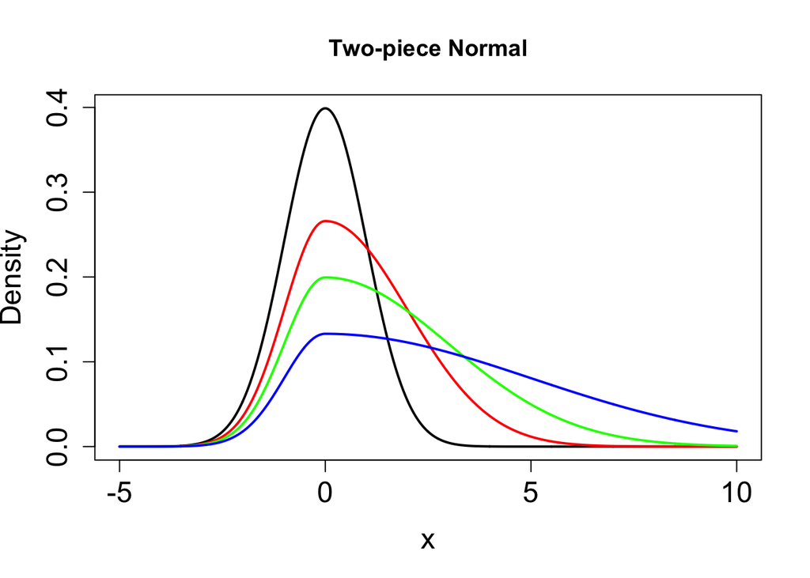

```r
# Two-piece normal density
dtpn <- function(x, mu = 0, sigma1 = 1, sigma2 = 1, log = FALSE){
  val <- dtp3(x, mu = mu, par1 = sigma1, par2 = sigma2, FUN = dnorm, param = "tp", log = log)
  return(val)
}

# Two-piece Cauchy density
dtpc <- function(x, mu = 0, sigma1 = 1, sigma2 = 1, log = FALSE){
  val <- dtp4(x, mu = mu, par1 = sigma1, par2 = sigma2, delta = 1, FUN = dt, param = "tp", log = log)
  return(val)
}

# Two-piece normal examples
f <- Vectorize(function(x) dtpn(x,0,1,1))

f1 <- Vectorize(function(x) dtpn(x,0,1,2))
f2 <- Vectorize(function(x) dtpn(x,0,1,3))
f3 <- Vectorize(function(x) dtpn(x,0,1,5))

# Two-piece Cauchy examples
h <- Vectorize(function(x) dtpc(x,0,1,1))

h1 <- Vectorize(function(x) dtpc(x,0,2,1))
h2 <- Vectorize(function(x) dtpc(x,0,3,1))
h3 <- Vectorize(function(x) dtpc(x,0,5,1))

# Figure 1a
U <- 10
L <- -5
curve(f,L,U, n= 1000, xlab = "x", ylab = "Density", main ="Two-piece Normal", lwd = 2, cex.axis = 1.5, cex.lab = 1.5)
curve(f1,L,U, n= 1000,add=T, col="red", lwd = 2)
curve(f2,L,U, n= 1000,add=T, col="green", lwd = 2)
curve(f3,L,U, n= 1000,add=T, col="blue", lwd = 2)
```

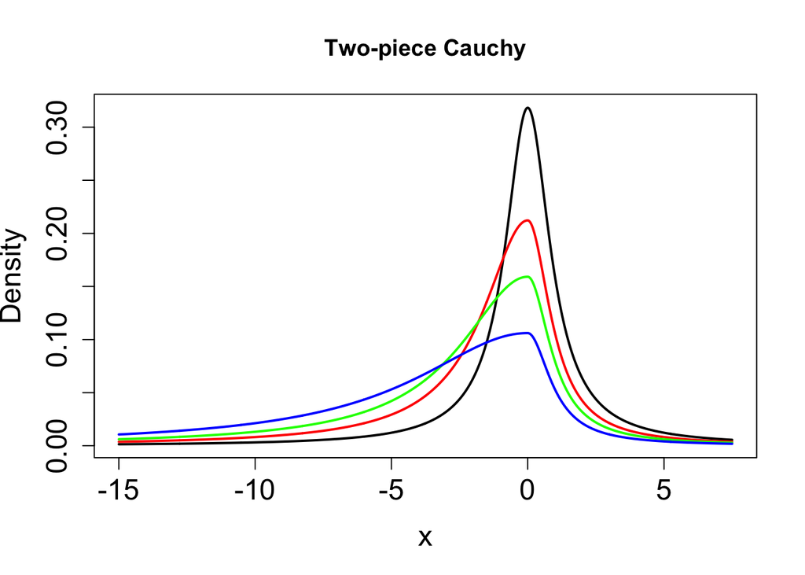

```r
# Figure 1b
U <- 7.5
L <- -15
curve(h,L,U, n= 1000, xlab = "x", ylab = "Density", main ="Two-piece Cauchy", lwd = 2, cex.axis = 1.5, cex.lab = 1.5)
curve(h1,L,U, n= 1000,add=T, col="red", lwd = 2)
curve(h2,L,U, n= 1000,add=T, col="green", lwd = 2)
curve(h3,L,U, n= 1000,add=T, col="blue", lwd = 2)
```

Arellano-Valle, R.B., H.W. Gómez, and F.A. Quintana. 2005. “Statistical Inference for a General Class of Asymmetric Distributions.” *Journal of Statistical Planning and Inference* 128 (2): 427–43.

Fechner, G.T. 1897. *Kollektivmasslehre*. Leipzig: Engelmann.

Rubio, F.J., and M.F.J. Steel. 2014. “Inference in Two-Piece Location-Scale Models with Jeffreys Priors.” *Bayesian Analysis* 9 (1): 1–22.

———. 2020. “The Family of Two-Piece Distributions.” *Significance* 17 (1): 12–13.